# Simulations

Alice Tivarovsky

10/31/2019

# Slides

Simulations are super useful in statistics.

# Examples

Setup code:

## Simulation: Simple Linear Regression for one n

In writing functions we wrote a short function to simulate data from a simple linear regression, fit the regression model, and return estimates of regression coefficients. Specifically, we generate data from yi=β0+β1xi+ϵi

for subjects 1≤i≤n with ϵi∼N[0,1] and return estimates

β̂0,β̂1

. That function is below.

```r
sim_regression = function(n, beta0 = 2, beta1 = 3) {

  sim_data = tibble(
    x = rnorm(n, mean = 1, sd = 1),
    y = beta0 + beta1 * x + rnorm(n, 0, 1)
  )

  ls_fit = lm(y ~ x, data = sim_data)

  tibble(
    beta0_hat = coef(ls_fit)[1],
    beta1_hat = coef(ls_fit)[2]
  )
}
```

We can run this as many times as we want:

```r
sim_regression(n = 30)
```

```
## # A tibble: 1 x 2
##   beta0_hat beta1_hat
##       <dbl>     <dbl>
## 1      2.09      3.04
```

## Re-run simulation using for loop

Important statistical properties of estimates β̂0,β̂1 are established under the conceptual framework of repeated sampling. If you could draw from a population over and over, your estimates will have a known mean and variance:

β̂0∼[β0,σ2(1n+x¯∑(xi−x¯)2)] and β̂1∼[β1,σ2∑(xi−x¯)2]

(Because our simulation design generates errors from a Normal distribution we also know that the estimates follow a Normal distribution, although that’s not guaranteed by least squares estimation.)

In the real world, drawing samples is time consuming and costly, so “repeated sampling” remains conceptual. On a computer, though, drawing samples is pretty easy. That makes simulation an appealing way to examine the statistical properties of your estimators.

Let’s run sim_regression() 100 times to see the effect of randomness in ϵ on estimates β̂0,β̂1

```r
output = vector("list", 100)

for (i in 1:100) {
  output[[i]] = sim_regression(30)
}

sim_results = bind_rows(output) #bind_rows function puts everything together
```

Taking a look at the for loop we used to create these results, you might notice that there’s no input list – the sequence is used to keep track of the output but doesn’t affect the computation performed inside the for loop. In cases like these, the purrr::rerun function is very handy.

```r
sim_results =
  rerun(100, sim_regression(30, 2, 3)) %>%
  bind_rows()
```

Structurally, rerun is a lot like map – the first argument defines the amount of iteration and the second argument is the function to use in each iteration step. As with map, we’ve replaced a for loop with a segment of code that makes our purpose much more transparent but both approaches give the same results.

Let’s make some quick plots and compute some summaries for our simulation results.

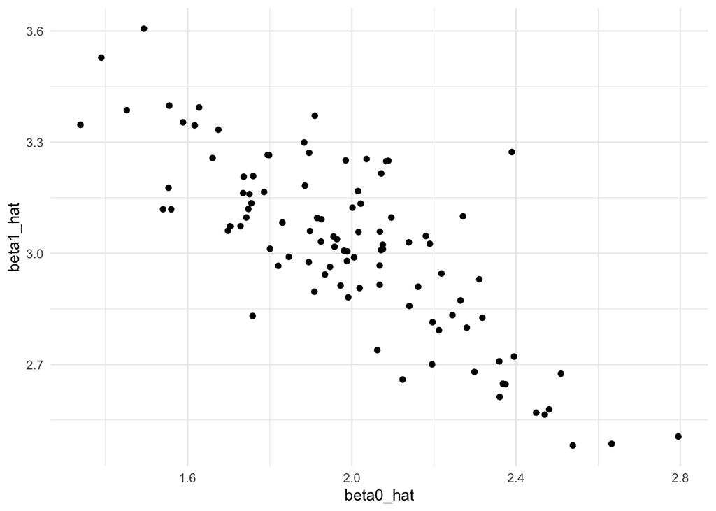

```r
sim_results %>%
  ggplot(aes(x = beta0_hat, y = beta1_hat)) +
  geom_point()
```